# Exploratory_analysis_eelgrass_2017

Wendel Raymond

December 11, 2017

# Exploratory analyses summer 2017

We collected a lot of data this past summer which are creating more questions than answers. Here are the highlights of analyses so far. For more see the Figures folder in the Seagrass 2017 sections of the APECS-ak GitHub repository. I also hope that this summary document helps convince everyone (especially people that will be running lots of analyses) that things like R Markdown and GitHub are really useful for a collaborative project.

## Where we worked

We covered a lot of ground this past summer. Click on an eelgrass icon to see the site name!

[interactive chart not shown]

## Sea otters

Our primary questions for this part of the APECS project what effect, if any, do sea otters have in eelgrass ecosystems in Southeast Alaska. To get at this we have compared many of our response metrics to our sea otter index. Since we only sampled sites once we are also concerned that time is an important factor to keep control of. So the following set of plots will present the sea otter index and time for comparison.

This schematic summarizes the “Elkhorn Slough Model” of sea otters and seagrass/eelgrass. When sea otters moved in they reduced the crab population, releasing grazers from predation which lead to heavy grazing on epiphytes. This lead to increased seagrass growth and biomass.

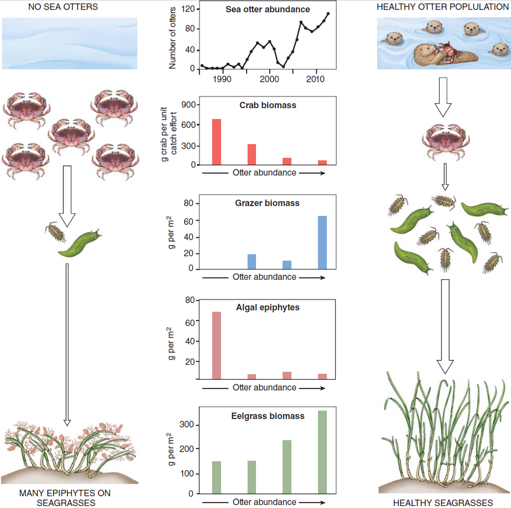

The sea otter index is a number or score assigned to each of our sites that combines our boat based sea otter surveys, calm and pit survey, known sea otter duration, and population model density estimates. This was done using a PCA and is plotted below. *Note that this color scheme is used throughout the document. Red = lots of sea otter impacts. Blue = less sea otter impacts.*

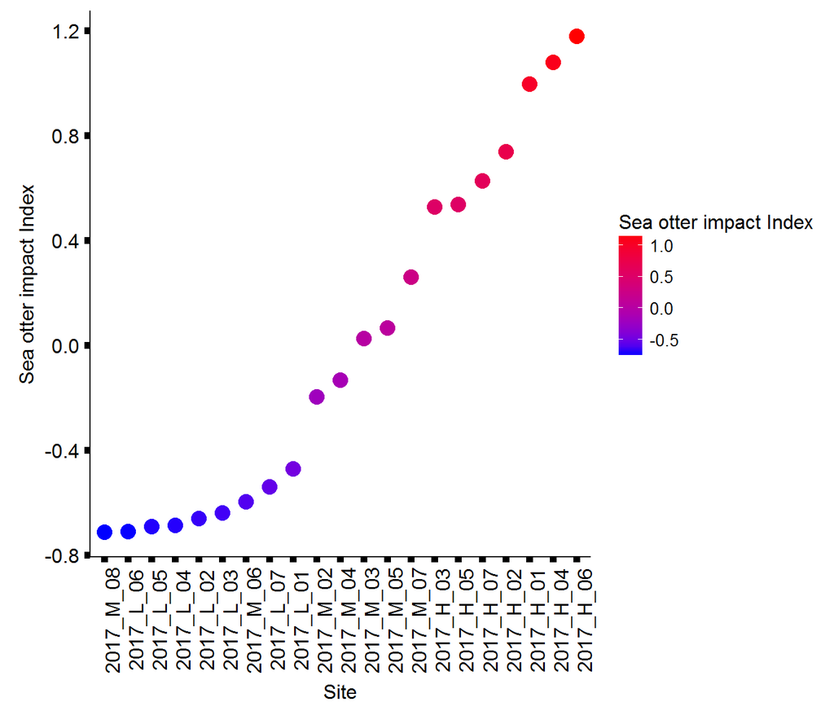

## Overview

From our exploratory analyses, which is only plots at this point so statistical tests, there appears to be little to no effect of sea otters on our responses of interest. There are some interesting patters with shoot density and aboveground biomass which may be evidence of a sea otter effect. However, in the case of shoot density it is important to remember that many things can impact shoot density, like sediment size. Alternatively low shoot density in high sea otter sites could be the results of direct disturbance (sea otter pits). In the case of aboveround biomass it is important too look at the plot versus time, where there is a very clear positive relationship.

Sea otters do appear to have a strong effect on crab biomass, which is what we expected. However, there is no relationship between crab biomass and grazer biomass. This makes us wonder if crabs are not a major predator of grazers in our system. One possible explanation is that crabs may be eating a lot of clams instead of grazers (see plots on proportion of predation type on clams). In terms of grazers effect on epiphytes, the plot is noisy but after consulting some literature this is possibly the expected relationship.

The fish data needs some more analysis but it would be interesting to see in any species or groups of species have convincing relationships with grazers. In other seagrass systems (Baltic Sea for example) fishes are a major predator on grazers.

Moving forward (as of 12/20/2017) we are developing hypotheses to test with the hopes of writing a paper focused on the trophic structure of eelgrass beds around POW and how sea otters effect (or don’t) them. Stay tuned!

### Plots - Primary Producers

**Set 1** - shoot density, above and belowground biomass.

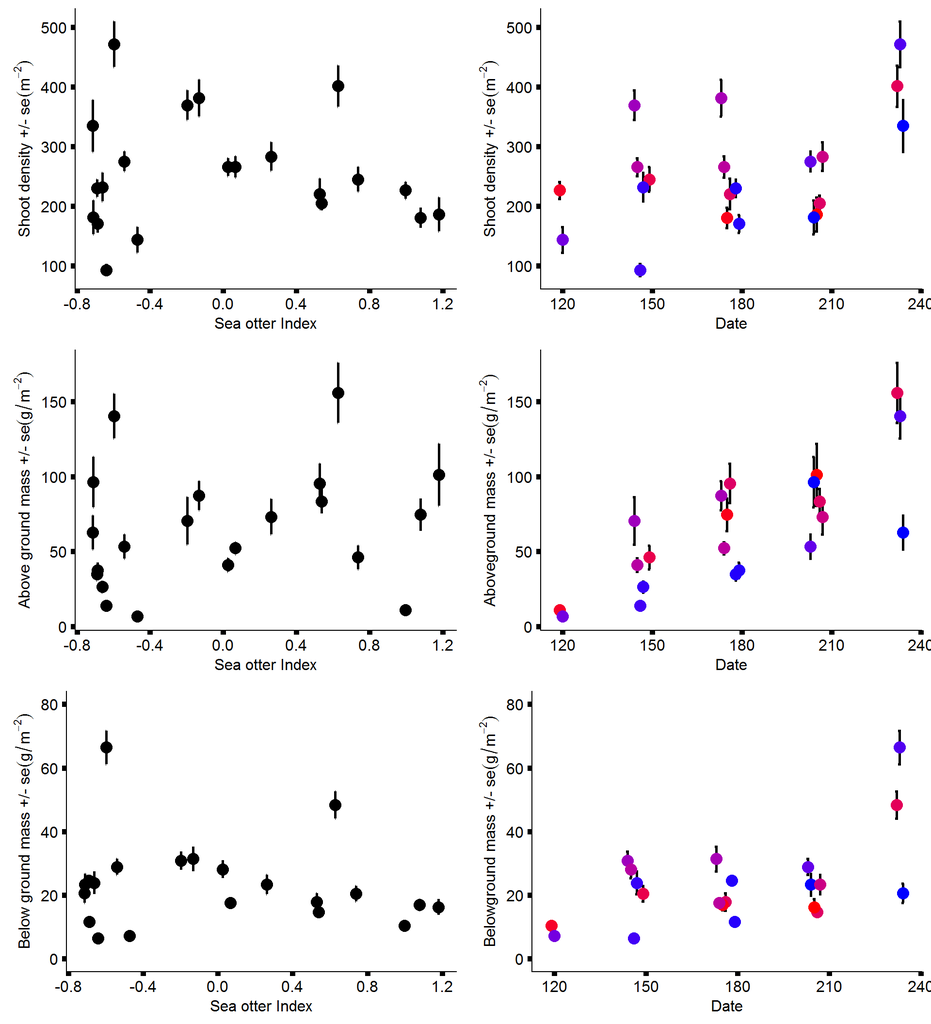

**Set 2** - epiphytes, diatom and macroalgae percent cover.

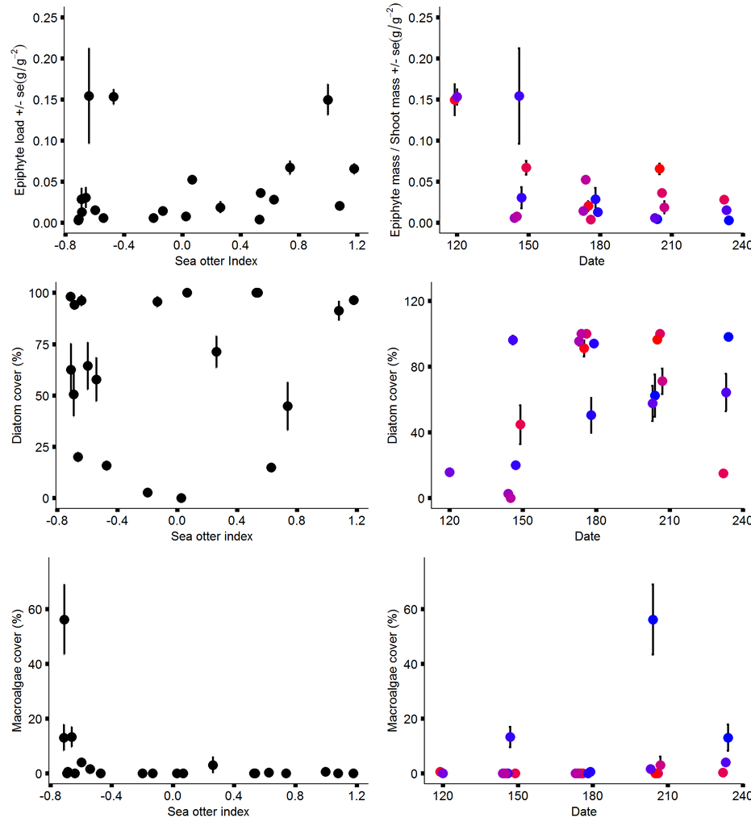

### Plots - Nutrients

Total nitrogen and N:P on the day of sampling (when we did the eelgrass data collection) and on nutrient day (when we sampled every site in one day).

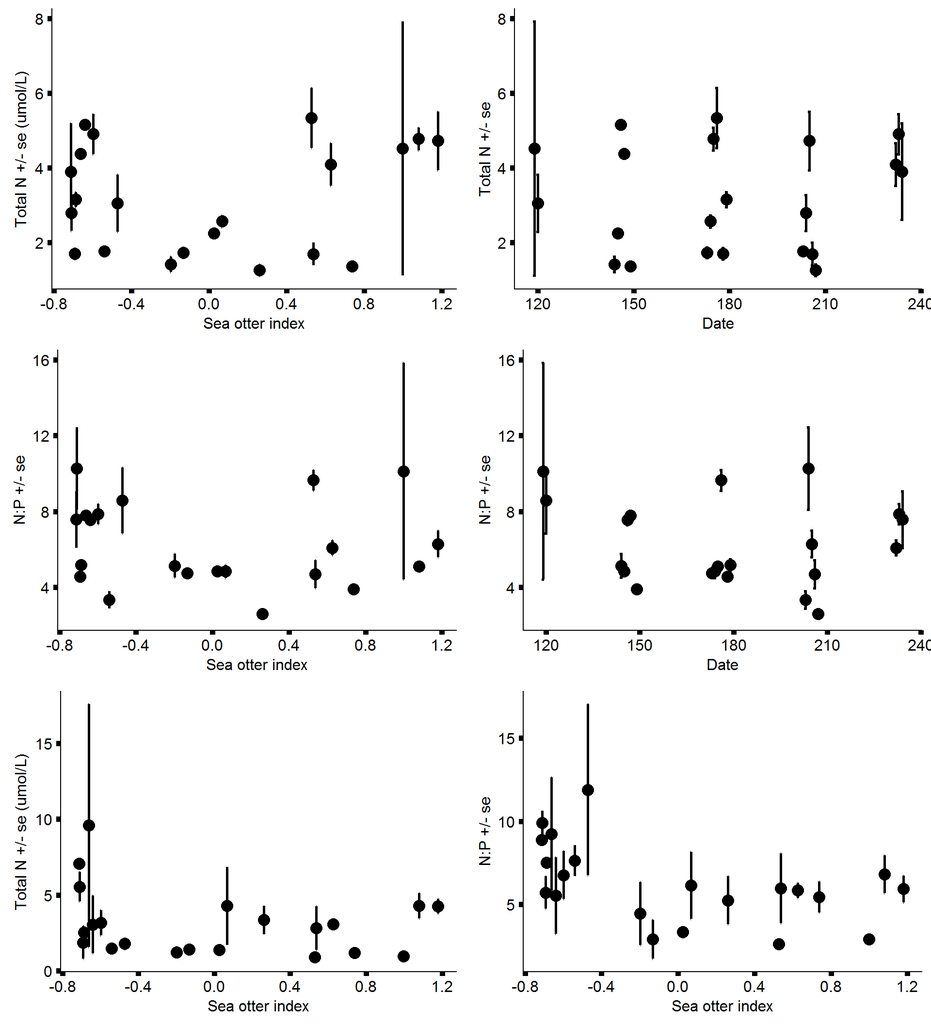

## Grazers

Broken down by total, crustacean, and gastropod grazers.

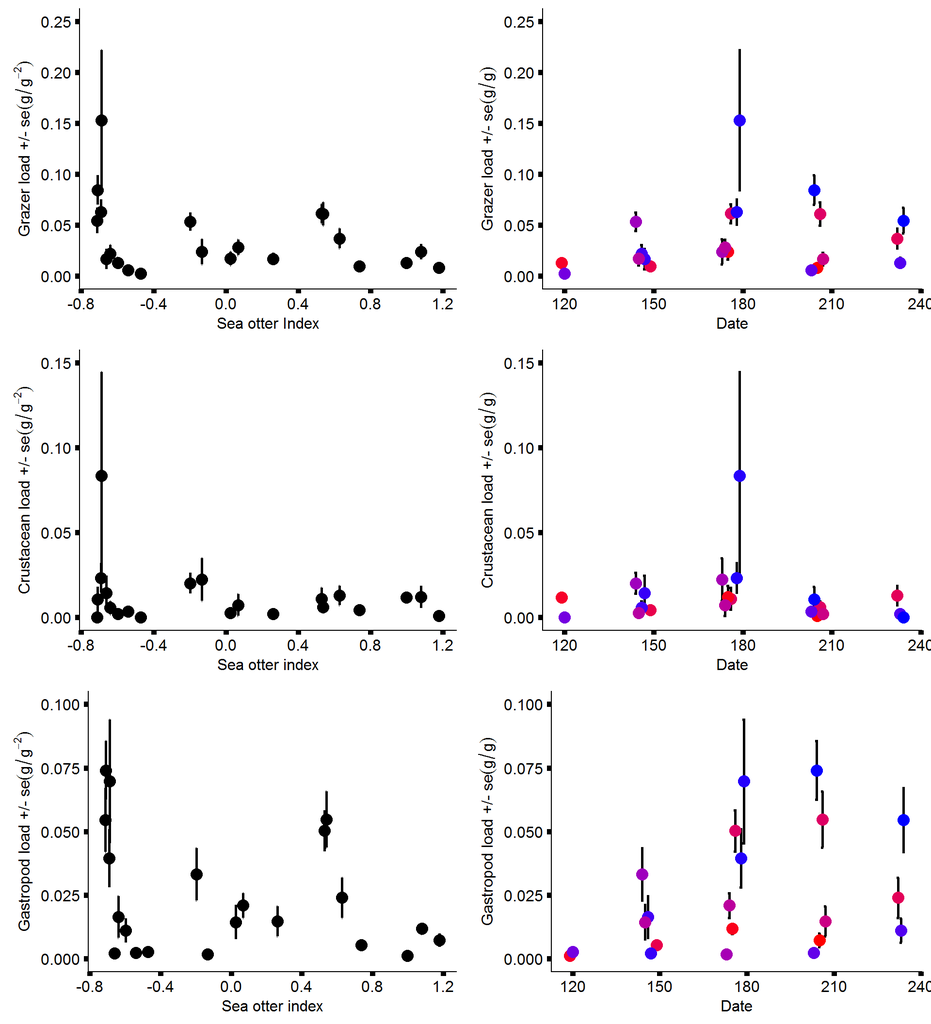

## Crabs

These are simple univariate summaries. Multivariate analysis will definitely be helpful, but are more time consuming. We would rather have more defined hypotheses before we dive into that analysis.

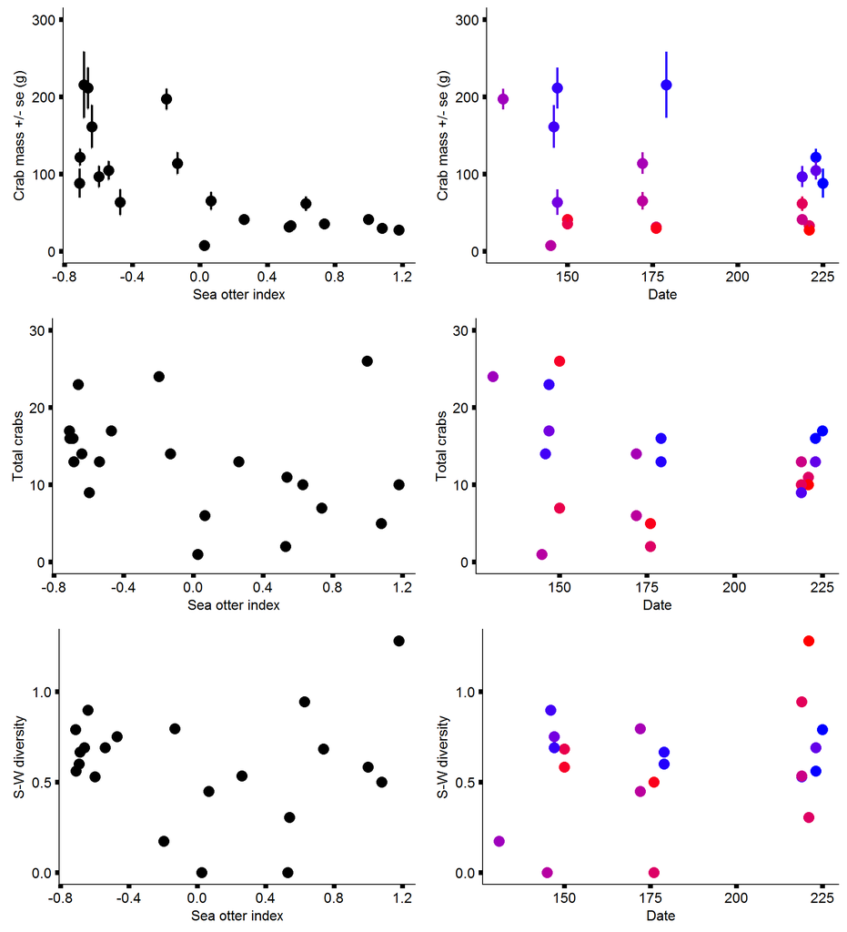

## Fish

Like with the crab data we are only presenting univariate summaries right now.

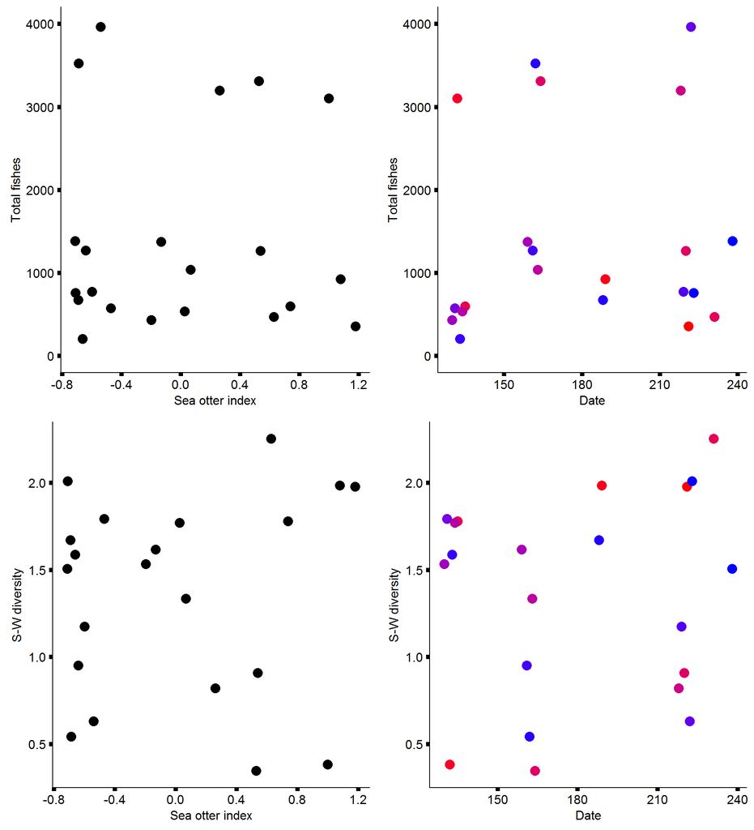

## Other comparisons

Grazers, epiphytes, crabs, and fish.

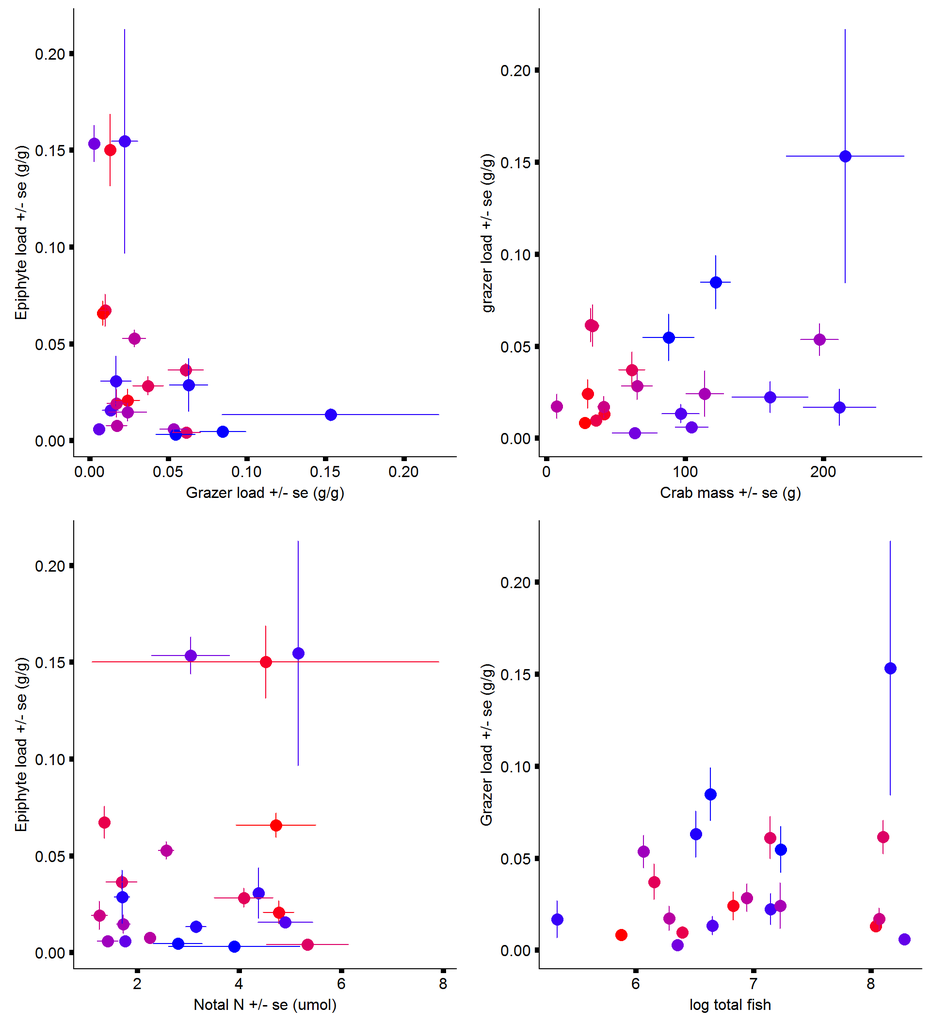

Log transformed grazer load vs epiphyte load.

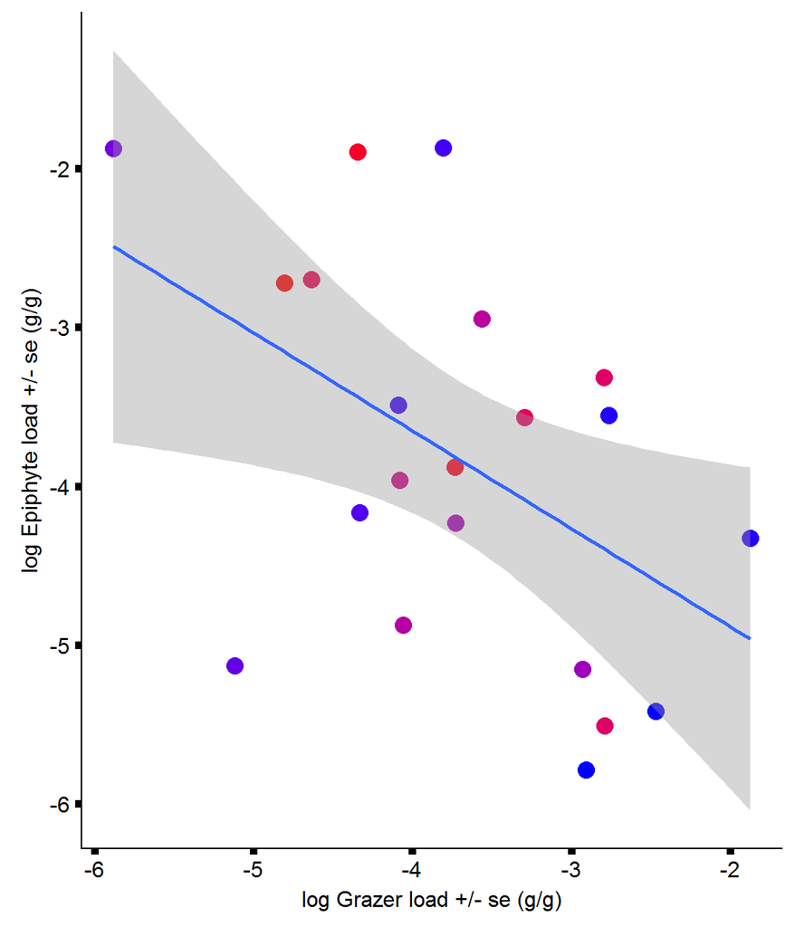

Summary from clam and pit surveys. **Sea otter pits**

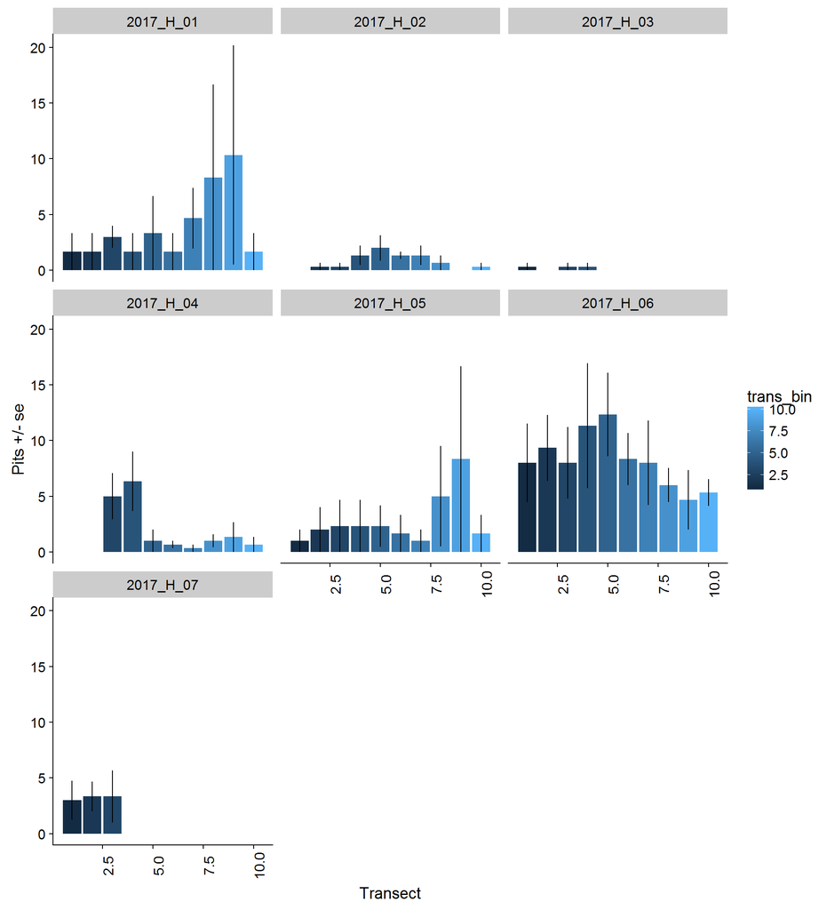

**Clams**

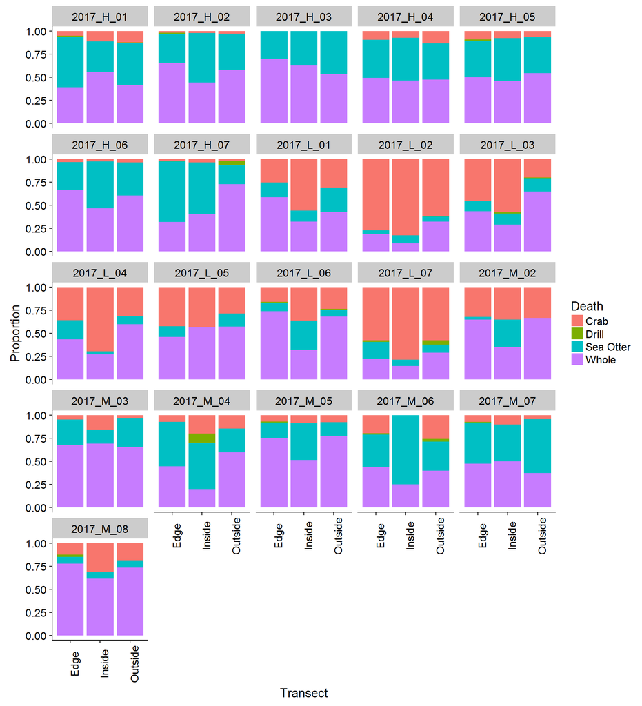

**Sediments** Sediment value corresponds to size category. Smaller the number, smaller the grain size.

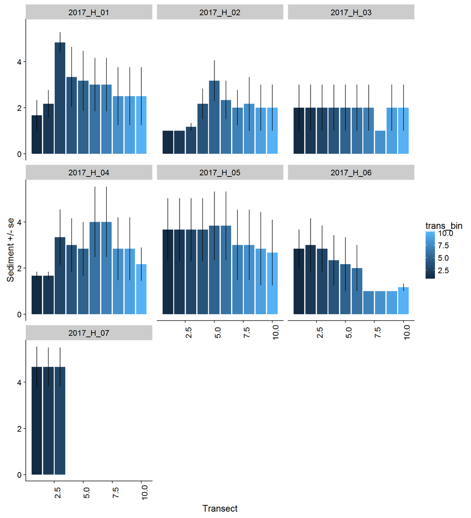